# Project1_olgol-19

olgol-19

October 1, 2019

Data was provided by [**Urban Ministries of Durham**](http://www.umdurham.org/).

Urban Ministries of Durham (UMD) operates the Food Pantry and Clothing Closet and Community Cafe to address basic emergency needs for food, clothing, diapers and hygiene supplies.

# Data cleaning

I will use only non-character variables for analysis.

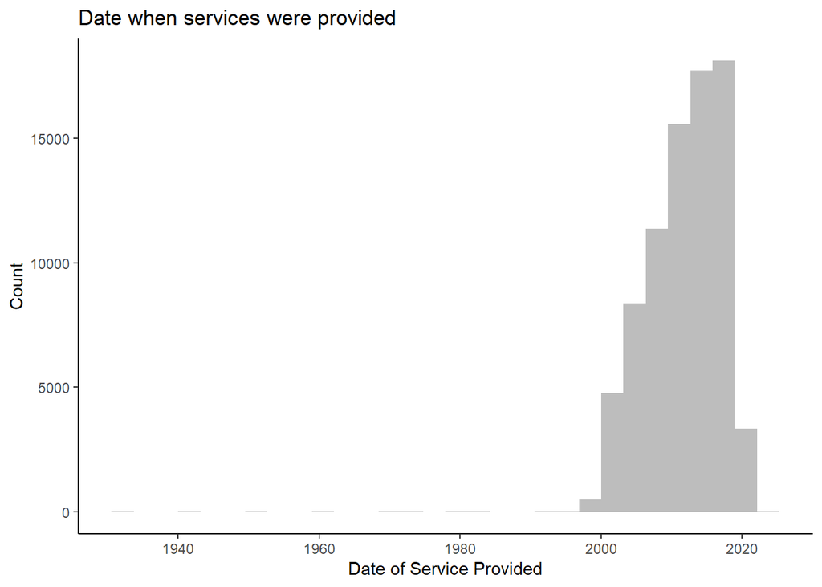

```r
UMD_data <- read_tsv("https://raw.githubusercontent.com/biodatascience/datasci611/gh-pages/data/project1_2019/UMD_Services_Provided_20190719.tsv") %>%
  mutate(N_Date = as.Date(Date, "%m/%d/%Y")) %>%
  select_if(~!is.character(.)) %>% # removing all character variables
  select_if(~!is.logical(.)) %>% # removing all logical variables
  arrange(N_Date)

# Visualize the date when services were provided
ggplot(data = UMD_data, aes(x=N_Date)) +
  geom_histogram(alpha = 0.4) +
  theme_classic() +
  xlab("Date of Service Provided") +
  ylab("Count") +
  ggtitle("Date when services were provided")
```

UMD was estabblished in 1983, so it is possible that data provided before this date might be not relevant or mistaken. We can also see that almost *no information* provided for the dates before year 2000.

# Filter the data

```r
UMD_cld <- UMD_data %>%
  filter(between(N_Date, as.Date("2000-01-01"), as.Date("2019-06-30"))) %>%
  mutate(Year = as.numeric(format(N_Date, "%Y"))) # created Year variable
```

# Total clients supported by year

In this section I wil determine the number of clients supported by year to find is there any trends which we can use for future?

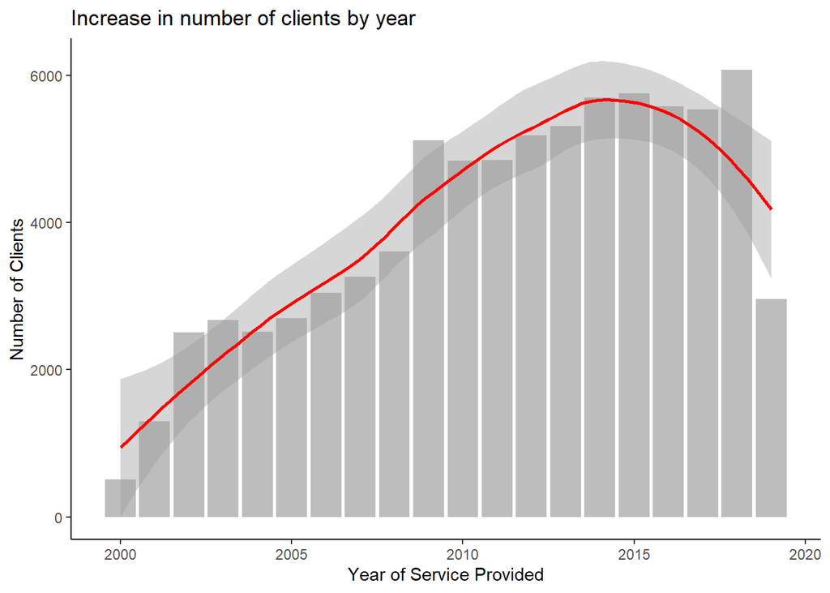

```r
clients = UMD_cld %>%
  group_by('Client file number', Year) %>%
  summarize(N_Client=n())

# Print the result

ggplot(clients, aes(Year, N_Client)) +
  geom_col(alpha = 0.4) +
  geom_smooth(color='red')+
  theme_classic()+
  xlab("Year of Service Provided") +
  ylab("Number of Clients") +
  ggtitle("Increase in number of clients by year")
```

We can clearly see that number of clients per year were increasing from 2000 to 2014 and quite satble in the last five years.

# Food pounds provided per year

As we know that food help is one of the most important services provided by UMD. I will determine the trend of pounds of food provided to customers each year for the next firve years. I think this might be helpfull for UMD to determine requid space for storage and funding.

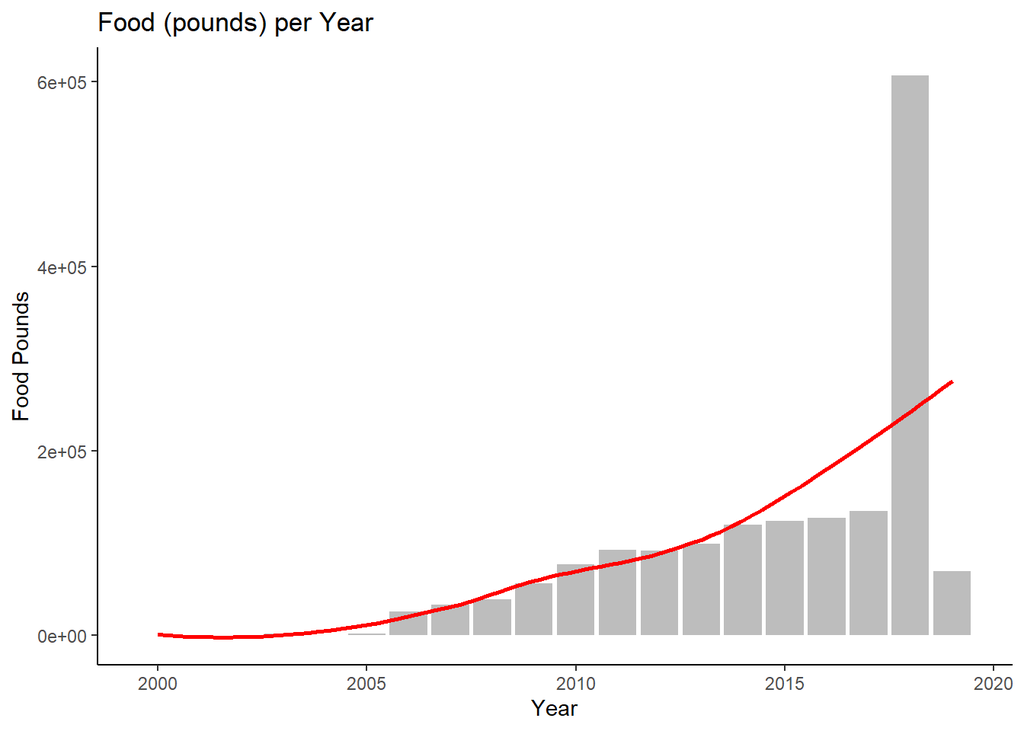

```r
food_df <- UMD_cld %>%
  drop_na(`Food Pounds`) %>%
  group_by(Year) %>%
  summarise(count = n(),food = sum(`Food Pounds`))

ggplot(food_df,aes(x = Year, y = food)) +
  geom_col(alpha = 0.4) +
  geom_smooth(color='red', se=FALSE) +
  theme_classic() +
  labs(title = 'Food (pounds) per Year',
       y = 'Food Pounds')
```

# How much food (in pounds) will be provided for next 5 years?

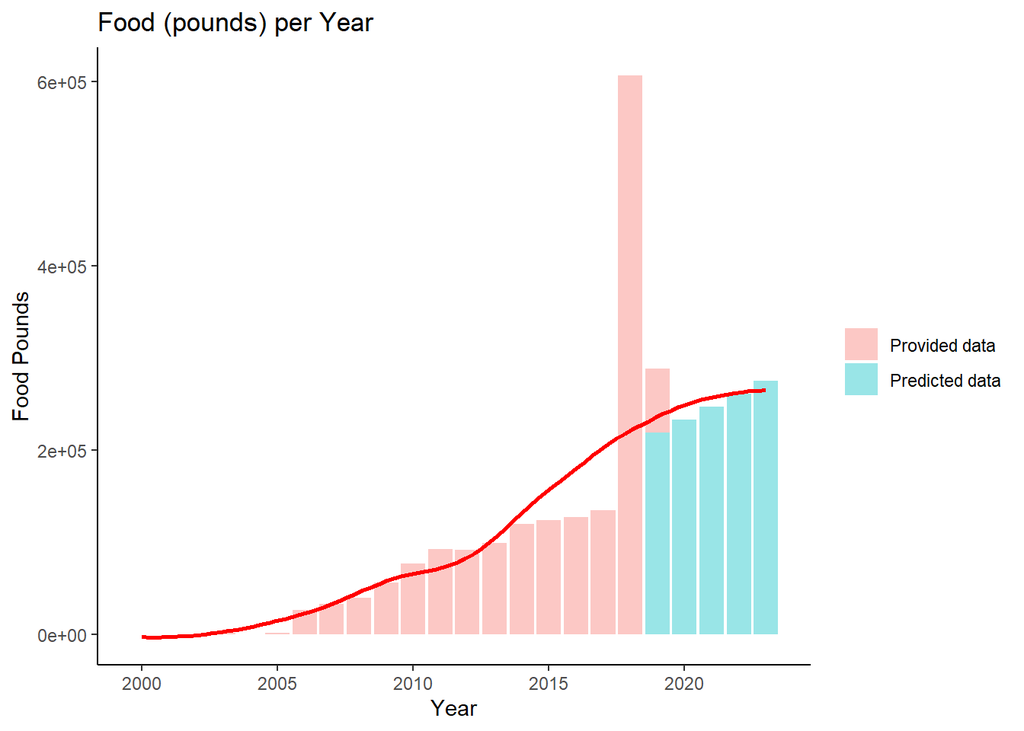

```r
food_model=lm(food ~ Year, food_df) # applied linear model

pred_years <- data.frame(Year=c(2019, 2020, 2021, 2022, 2023))

prd <- data.frame(predict(food_model, pred_years))

pred_df <- cbind(pred_years, prd)  %>%
  mutate(prd_f=as.factor(2))

names(pred_df)[2] <- 'food'

# Plot the data together with predicted values

new_food_df <- food_df %>%
  select(-count) %>%
  mutate(prd_f=as.factor(1)) %>%
  rbind(pred_df)

ggplot(new_food_df,aes(x = Year, y = food)) +
  geom_col(alpha = 0.4, aes(fill=prd_f)) +
  geom_smooth(color='red', se=FALSE) +
  theme_classic() +
  labs(title = 'Food (pounds) per Year',
       y = 'Food Pounds')+
  theme(legend.title = element_blank()) +
  scale_fill_discrete(labels=c("Provided data", "Predicted data"))
```

This data shows that the pounds of of which will be provided for next five years may still grow. This data may help UMD to prepara enogh food for their clients.

# Distribution of diapers by year

In this section we will plot the data about diapers help by year for all clients.

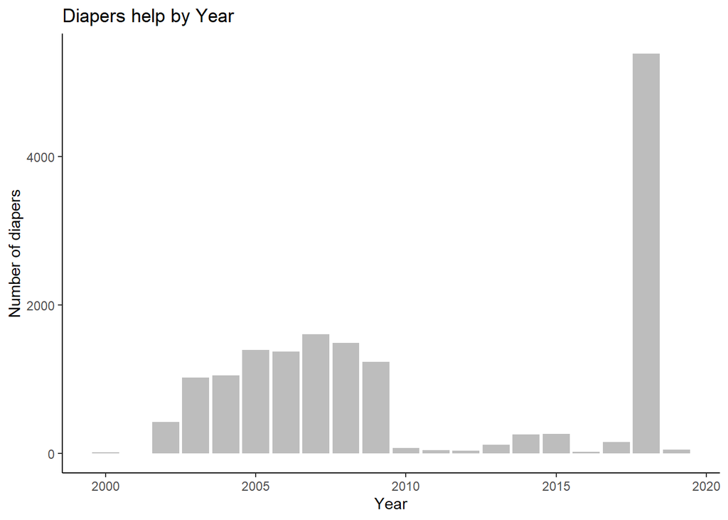

```r
UMD_cld %>%
  drop_na('Diapers') %>%
  group_by(Year) %>%
  summarise(count = n(),diapers=sum(Diapers)) %>%
  ggplot(aes(x = Year, y = diapers)) +
  geom_col(alpha = 0.4) +
  theme_classic() +
  labs(title = 'Diapers help by Year',
       y = 'Number of diapers')
```

The data shows there was a decrease in this type of help starting from 2010, except year 2018.

# Distribution of clothing items by year

In this section we will plot the data about closing items help by year for all clients.

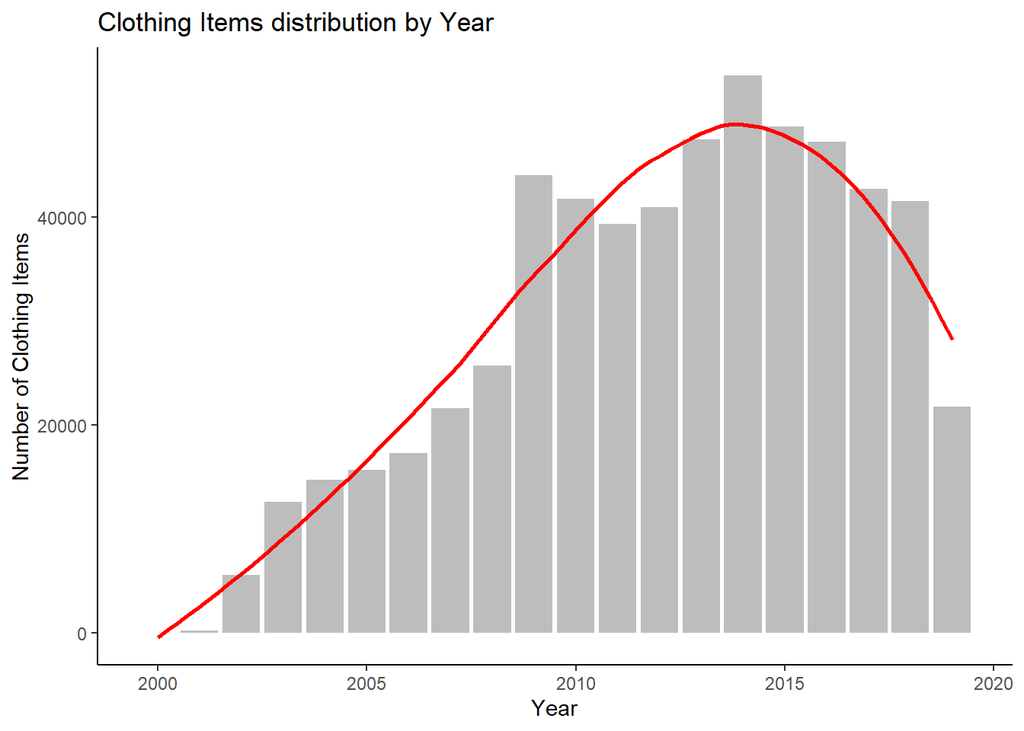

```r
UMD_cld %>%
  drop_na(`Clothing Items`) %>%
  group_by(Year) %>%
  summarise(count = n(),cloth=sum(`Clothing Items`)) %>%
  ggplot(aes(x = Year, y = cloth)) +
  geom_col(alpha = 0.4) +
  geom_smooth(color='red', se=FALSE) +
  theme_classic() +
  labs(title = 'Clothing Items distribution by Year',
       y = 'Number of Clothing Items')
```

We can clearly see that closing items stil remain very important help for UMD customers.

# Distribution of School kits by year

In this section we will plot the data about distribution of schools supplies help by year for all clients.

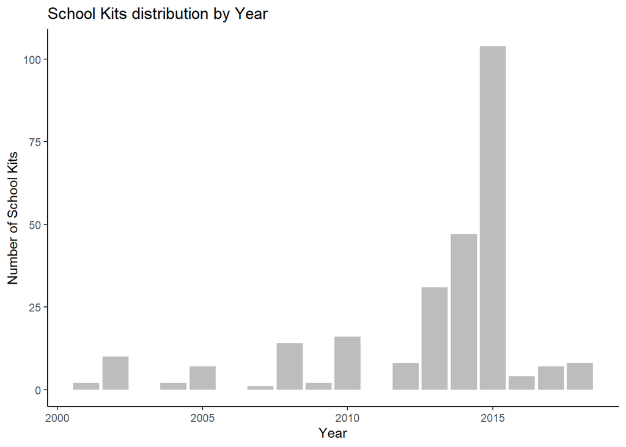

```r
UMD_cld %>%
  drop_na(`School Kits`) %>%
  group_by(Year) %>%
  summarise(count = n(), school=sum(`School Kits`)) %>%
  ggplot(aes(x = Year, y = school)) +
  geom_col(alpha = 0.4) +
  theme_classic() +
  labs(title = 'School Kits distribution by Year',
       y = 'Number of School Kits')
```

There is no clear trend on school kits help for the last years.

# Distribution of Hygiene kits by year

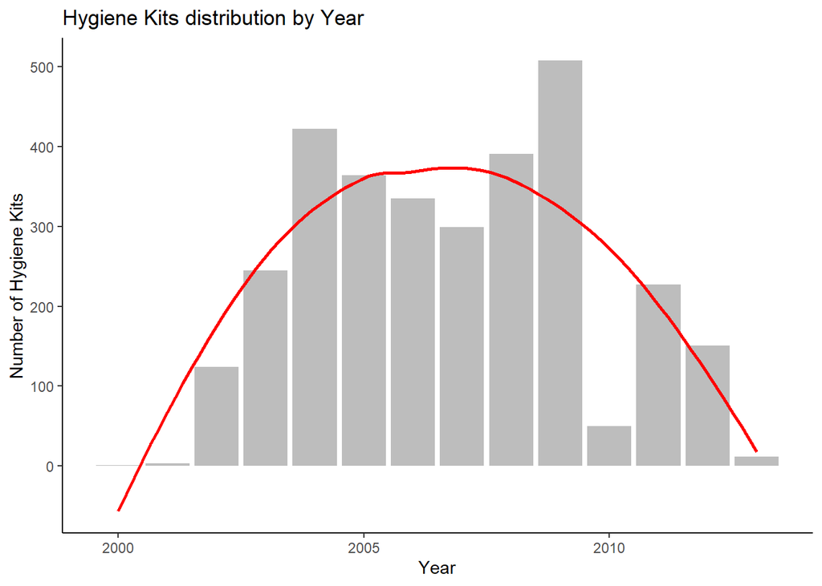

```r
UMD_cld %>%
  drop_na(`Hygiene Kits`) %>%
  group_by(Year) %>%
  summarise(count = n(), kit = sum(`Hygiene Kits`)) %>%
  ggplot(aes(x = Year, y = kit)) +
  geom_col(alpha = 0.4) +
  geom_smooth(color='red', se=FALSE) +
  theme_classic() +
  labs(title = 'Hygiene Kits distribution by Year',
       y = 'Number of Hygiene Kits')
```

The hygiene kits heps seems to be decrising over the last 5 years.

# Average family size (by column food provided for)

I will calculate the average family size to help the UMD predict the amount of food needs for each family.

```r
family_size <- UMD_cld %>%
  select(`Food Provided for`) %>%
  filter(`Food Provided for`>0) %>%
  drop_na(`Food Provided for`) %>%
  rename(food=`Food Provided for`)

mean(family_size$food)
```

```
## [1] 2.779725
```

The average family size is 2.8 people.

# Conclusion

In this project I tried to present the data provided by Urban Ministry of Durham. Data visualisation can help the UMD to see better see previos data summary to serve homeless people more efficient.